Original article

Recombinant human activated protein C as a disease modiﬁer in severe acute

pancreatitis: Systematic review of current evidence

Charles J. Miranda, Benoy I. Babu, Ajith K. Siriwardena*

Hepatobiliary Surgery Unit, Manchester Royal Inﬁrmary, Oxford Road, Manchester M13 9WL, UK

Keywords:

Human recombinant activated protein C

Drotecogin Alfa

Pancreatitis

a b s t r a c t

Background: The severity of organ failure caused by acute pancreatitis (AP) is the most important

determinant of mortality in the disease. Recombinant human activated protein C (Drotrecogin Alfa;

Xigris, APC, rhAPC) is the ﬁrst drug to show a decrease in all-cause mortality due to multiple organ failure

caused by sepsis. As the systemic inﬂammatory response syndrome (SIRS) that causes organ failure in

early AP is similar to that caused by severe sepsis, the use of rhAPC in the management of AP has been

investigated in experimental and clinical studies which are collated in this review.

Methods: A literature review of published material identiﬁed from MEDLINE and EMBASE databases, for

the period from January 1985 to January 2011, reporting rhAPC usage in AP.

Results: 3 of 4 experimental studies reported an improvement in outcome in animals with AP given

rhAPC. The clinical randomized trial showed no improvement in outcome in the treatment arm.

Conclusion: The experimental evidence of disease amelioration in AP following intervention with rhAPC

has not translated to the small clinical RCT. Given that there were only 16 patients in the treatment arm,

further clinical evaluation is justiﬁed.

Copyright � 2012, IAP and EPC. Published by Elsevier India, a division of Reed Elsevier India Pvt. Ltd. All

rights reserved.

1. Introduction

Severe acute pancreatitis (SAP) is characterized by the co-

existence of local peri-pancreatic complications with sustained

organ failure [1]. The treatment remains essentially supportive and

comprises careful and adequate ﬂuid resuscitation together with

support for cardiovascular, respiratory and renal systems in addi-

tion to appropriate analgesia [2,3]. Prophylactic antibiotic therapy

[4e6], early enteral nutrition [7,8] and early endoscopic sphinc-

terotomy [9] for patients with biliary acute pancreatitis and

features of bile duct obstruction are the only speciﬁc interventions

for which there is supportive randomized trial evidence. However,

none of these interventions are universally accepted as genuinely

ameliorating the disease course and in the case of antibiotics in

particular, current guidance does not favor prophylaxis.

Given that the early stage of severe acute pancreatitis does not

require surgical intervention [10,11], this phase of the disease is

ideally and logically suited to pharmacological intervention aimed

at disease modiﬁcation. Many drugs have been evaluated as speciﬁc

pharmacological

treatments

for

severe

acute

pancreatitis.

Disappointingly, the unifying characteristic of the drugs that have

been evaluated to date has been their lack of efﬁcacy as effective

disease-ameliorating treatments for severe acute pancreatitis.

Whilst it is thought that some of this apparent lack of efﬁcacy may

relate to the over-broad categorization of severe acute pancreatitis

in the 1992 Atlanta consensus criteria [1] resulting in patients with

transient or minimal organ failure (and thus a likely mild clinical

course) being incorrectly categorized as severe, it remains the case

that there is to date, no speciﬁc pharmacological treatment for

severe acute pancreatitis.

One strategy in the search for speciﬁc interventions is to

consider treatments that have been effective in disease states that

are similar to SAP. Severe sepsis has similarities to SAP; both are

characterized by an exaggerated systemic inﬂammatory response

syndrome (SIRS). Inﬂammation involves a pathophysiological

derangement of the endogenous anticoagulant pathways involved

in the maintenance of microvascular patency [12] with microvas-

cular thrombosis and disseminated intravascular coagulation being

a critical outcome [13]. The protein C pathway plays a major role in

preventing microvascular thrombosis [14]. Endogenous protein C is

depleted in a primate model of Escherichia coli-induced sepsis

resulting in microvascular thrombosis, the harmful effects of which

are ameliorated by intravenous infusion of recombinant human

active protein C molecule (rhAPC) [15]. Based on these key

* Corresponding author. Tel.: þ44 161 276 4250; fax: þ44 161 276 4530.

E-mail address: ajith.siriwardena@cmft.nhs.uk (A.K. Siriwardena).

[figure not shown]

[figure not shown]

experimental ﬁndings, human recombinant activated protein C

(Xigris, Eli Lilly, Indianapolis, IN) was evaluated in a major

randomized trial in patients with sepsis (the PROWESS study [16]).

The PROWESS study demonstrated that treatment was associated

with a signiﬁcant reduction in mortality.

SAP is characterized by pancreatic and peri-pancreatic necrosis

in addition to SIRS. Microvascular thrombosis is likely to be one of

the mechanisms involved in the mediation of pancreatic necrosis.

Thus a hypothetical case can be made that Xigris may have a role as

an early and speciﬁc disease-modulating drug in SAP for its roles in

maintaining microvascular patency and down regulating the

inﬂammatory response.

An important caveat is that acute pancreatitis was one of the

listed exclusion criteria in the PROWESS study [Appendix 2 [16]].

SAP is associated with a risk of peri-pancreatic hemorrhage and

thus the use of a drug with potent anticoagulant properties may

lead to bleeding-related complications.

The potential role of rhAPC as a speciﬁc pharmacological treat-

ment for SAP was recognized by Alsfasser and colleagues who

undertook the ﬁrst evaluation of this drug in this setting [17]. Since

their initial report, experience with RHAPC in experimental acute

pancreatitis has accrued and a small clinical randomized trial has

also been undertaken.

Considering the history of unsuccessful pharmacological inter-

ventions in SAP the aim of this study is to undertake a detailed

systematic review of the evidence for rhAPC as a disease modiﬁer

and to address whether there is sufﬁcient evidence for an appro-

priately constituted randomized trial to evaluate this drug in SAP.

2. Methods

2.1. Literature search and data retrieval strategy

A computerized search was performed of the MEDLINE and

EMBASE databases for the period from January 1985 to January

2011 using the OVID search engine (Version 10.5.1, Source ID

1.13281.2.21; Ovid Technologies, Inc., New York, NY, USA). The

search terms ‘Pancreatitis’, ‘Protein C’, ‘Activated Protein C’ and

‘Drotrecogin’ were used. The map term to subject (MeSH) heading

was employed where possible. Results were combined with the

keywords, with the aid of Boolean operators. There were 23 hits in

MEDLINE and 61 in EMBASE. The Cochrane systematic reviews

methodology was utilized to cross-reference combined EMBASE

and MEDLINE output with all clinical trials and studies including

experimental studies and any non-English studies. Letters and

reviews without original data were excluded, leaving a ﬁnal study

population of 8 manuscripts. The reasons for excluding manu-

scripts are provided in Fig. 1.

All retrieved manuscripts were reviewed by two authors (CJM,

BIB) and any difference of opinion regarding ﬁnal inclusion/exclu-

sion was resolved by discussion with the third author (AKS).

3. Results

3.1. Human recombinant activated protein C in experimental acute

pancreatitis

Four studies have evaluated the role of rhAPC in experimental

acute pancreatitis [17e20] (Tables 1 and 2). Of these, a further study

by Chen’s group was excluded, as there is a considerable apparent

overlap between the 2007 study [19] and the 2010 report [21].

All experimental studies have evaluated experimental acute

pancreatitisintheratmodel.Therearenodataon largeanimalmodels

of acute pancreatitis. All use a well-validated intra-ductal infusion

method to induce acute pancreatitis. A wide range of concentrations

of human recombinant activated protein C is evaluated.

The ﬁndings are not consistent. Yamanel and colleagues [18],

using 100 mg/kg rhAPC as a single dose at 6 h after induction,

report improvements in histologic features of pancreatic injury,

serum markers of inﬂammation and a reduction in bacterial

translocation. There was no evidence of pancreatic or intra-

abdominal hemorrhage.

Alsfasser’s [17] comprehensive report describes a concentra-

tion-dependent thrombocytopenia but no effect of the drug on

histologic scores of necrosis and edema with the 100 mg/kg/h

continuous infusion. The Alsfasser group is the only study to

examine mortality and they show a signiﬁcant reduction in

mortality in animals with AP treated with rhAPC compared to

animals with AP alone.

Chen’s study [19] provides detailed information on the effect of

rhAPC on the mitogen-associated protein kinase pathway demon-

strating a reduction in expression of stress proteins.

The Akay study [20] ﬁndings are in contrast to the others in that

they report no beneﬁcial effects from intervention with rhAPC. Of

note, the concentration of rhAPC used in their study parallels the

dose used in human sepsis (24 mg/kg/h).

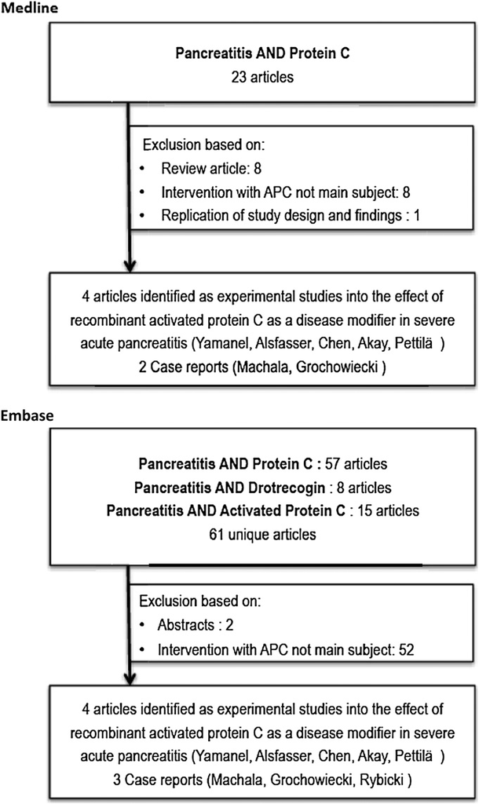

Fig. 1. Search strategy. Date range from January 1985 to January 2011. rhAPC ¼ human

recombinant activated protein C. AP ¼ acute pancreatitis.

3.2. Human recombinant activated protein C in clinical acute

pancreatitis

The APCAP study comprised a pilot, double blind, randomized

placebo-controlled trial (RCT) of intravenous infusion of rhAPC at

a ﬁxed dose of 24 mg/kg/h for 96 h in patients with SAP [22]. The

inclusion criteria were appropriately focused to deliver a target

population with severe disease: <96 h from onset of pain and at

least one organ dysfunction (deﬁned as organ speciﬁc Sequential

Organ Failure Assessment (SOFA) score of at least 3 or 4, within 48 h

of onset of the ﬁrst organ dysfunction).

The a priori primary endpoint was a three-point difference in

change of SOFA score with the authors predicting that this differ-

ence could be detected with a sample size of 32 patients were

randomized and 16 patients comprised the intervention group.

Baseline characteristics were similar and the mean � standard

deviation Acute Physiological and Chronic Health Evaluation II

(APACHE II) score in the rhAPC group was 17.6 � 8.5.

Their results showed no signiﬁcant bleeding events. The 30-day

mortality in the rhAPC group was 3 (19%) compared to 0 in the

placebo group. The primary endpoint was not met and there was no

signiﬁcant difference in SOFA score. An interesting observation was

that treatment with rhAPC was associated with an increase in serum

levels of both total and conjugated bilirubin. There were no differ-

ences in ventilator-free days, in renal replacement therapy-free

days, in vasopressor-free days or in days alive outside the hospital.

In addition to this principal randomized trial, there are case

report-level experiences of the use of rhAPC in severe acute

pancreatitis. The ﬁrst documented report of rhAPC use in severe

acute pancreatitis was by Machala and colleagues who reported

their

experience

with

2

patients

with

infected

pancreatic

necrosis [23]. In 2006, Grochowiecki and colleagues published

Table 1

Protocol details of studies evaluating human recombinant activated protein C in experimental acute pancreatitis. rhAPC ¼ Human recombinant activated protein C; AP ¼Acute

Pancreatitis; i.v. ¼ Intravenous; MAPK ¼ mitogen-activated protein kinases. CNI1493: a synthetic inhibitor of signal transduction, which inhibits phosphorylation of p38 MAPK.

First author

Animal

model

Study designation/

detail

Induction agent/route

Concentration of Xigris

Groups

Number of

animals

Study

duration

Yamanel [18]

2005

Rat

Effect of rhAPC

on AP

Intra-ductal 5% sodium

taurocholate

100 mg/kg single dose at

6 h after induction

Group I ¼ control

Group II ¼ AP

Group III ¼ AP þ rhAPC

45

24 h

Alsfasser [17]

2006

Rat

Safety assessment

of rhAPC

Intra-ductal saline plus i.v. cerulein

5 mg/kg/h for mild AP

Intra-ductal 10 mM glycodeoxycholic

acideglycylglycine and i.v.

cerulein (as above)

0.6 mL/kg/h or 100 mg/kg/h

Continuous infusion

Dose-ranging study: 12.5,

17, 21, 50 and

100 mg/kg/h rhAPC

15

(3 per

group)

6 h

Alsfasser [17]

2006

Rat

Treatment of

severe AP

Intra-ductal 10 mM glycodeoxycholic

acideglycylglycine and i.v. cerulein

100 mg/kg/h

Continuous infusion

Group 5: severe AP

Group 6: severe AP

and rhAPC

24

(12 per

group)

6 h

Alsfasser [17]

2006

Rat

rhAPC & survival

Intra-ductal 10 mM glycodeoxycholic

acideglycylglycine and i.v. cerulein

100 mg/kg/h

Continuous infusion

Group 7: severe AP

Group 8: severe AP

and rhAPC

16

(2 groups)

24 h

Chen [19] 2007

Rat

Effect of rhAPC

on MAPK

Intra-ductal 5% sodium taurocholate

10 mg/kg (low dose) or

50 mg/kg (high dose)

5 groups:

Control

AP

AP þ rhAPC low

dose (10 mg/kg)

AP þ rhAPC high

dose (50 mg/kg)

AP þ CNI1493*

75

16 h

Akay [20] 2008

Rat

Effect of rhAPC

on early phase

of AP

Intra-ductal 5% sodium

taurocholate

24 mg/kg/h as i.v. bolus

starting 4 h after induction

of AP

Laparotomy only

AP

AP þ drotrecogin

9 h

Table 2

Principal endpoints of studies evaluating Human recombinant activated protein C in experimental acute pancreatitis. rhAPC ¼ Human recombinant Activated Protein C;

AP ¼Acute pancreatitis; TNF-a ¼ Tumor necrosis factor alpha; IL-6 ¼ Interleukin-6; MPO ¼ Myeloperoxidase; MAPK ¼ mitogen-activated protein kinases; mRNA ¼ messenger

ribonucleic acid; JNK ¼ c-Jun N-terminal Kinases; ERK 1/2 ¼ Extracellular signal-regulated Kinases.

First author

Study

Principal endpoints

Yamanel [18]

Effect of rhAPC on AP.

rhAPC associated with marked reduction in pancreatic edema, necrosis without increase in hemorrhage.

rhAPC ameliorated serum amylase, TNF-a and IL-6.

rhAPC associated with a reduction in bacterial translocation to mesenteric nodes.

Alsfasser [17]

Safety assessment.

Concentration-dependent thrombocytopenia.

No evidence of bleeding.

Alsfasser [17]

Treatment of severe AP.

No difference in histologic scores of necrosis and edema.

Signiﬁcant reduction in pancreatic and pulmonary MPO.

Alsfasser [17]

rhAPC and survival.

6 of 7 (86%) survival in rhAPC group

3 of 8 (38%) in AP group.

Chen [19]

Effect of rhAPC on MAPK.

rhAPC-treatment resulted in reduction of histological evidence of pancreatic injury.

rhAPC-treatment was associated with decreased gene, mRNA and protein expression of p38 MAPK and JNK

with increased expression of ERK1/2.

rhAPC-treatment resulted in lower histological scores of pancreatic injury (including necrosis).

Akay [20]

Effect of rhAPC on early

phase of acute pancreatitis.

Mean serum amylase lower in treatment group.

No difference in histopathologic scores of injury.

No difference in pancreatic MPO activity.

No difference in serum interleukin-6 concentrations.

a report detailing their experience with human recombinant

activated protein C in the treatment of a patient with pancrea-

titis following the receipt of a transplanted pancreas [24].

Rybicki and colleagues report a further case treated with rhAPC

because of rapidly progressive multiple organ failure [25]. All

case reports describe a favorable outcome with no evidence of

treatment-related hemorrhage but clearly provide only limited

evidence.

4. Discussion

This report assesses the evidence for the evaluation of rhAPC as

a disease modifying drug in acute pancreatitis. As with almost all

other proposed disease modifying drugs, a body of evidence has

accrued from studies in experimental acute pancreatitis. Placed

together, rather than read in isolation, the relative similarities and

disparities of protocol design become readily evident (Tables 1 and

is its reproducibility and the resultant severe acute necrotizing

pancreatitis [26]. A theoretical disadvantage is the physical manip-

ulation of the pancreas in relation to assessment of an intervention,

which has pancreatic hemorrhage as a potential side effect. The

concentration of rhAPC used in the intervention groups and criti-

cally, the timing of intervention, vary considerably between studies.

We have previously reported that studies of experimental acute

pancreatitis can be broadly dichotomized into those that examine

mechanistic components of the pancreatic inﬂammatory process

and those that evaluate a potential speciﬁc therapy [27]. In this

regard, the Alsfasser study [17] is well-designed and executed and

reports a composite of a series of studies and is the sole experi-

mental study to evaluate the effect of rhAPC on mortality. As such,

although there is no formal process of weighting the importance of

experimental studies, the Alsfasser study [17] ﬁndings carry

considerable importance and their key ﬁnding of a reduction in

of bleeding is noteworthy. The failure to modify the histological

features of pancreatic injury raises the possibility that beneﬁcial

effects of rhAPC are from actions out with the pancreas. The studies

of Yamanel [18] and Chen [19] are broadly supportive of Alsfasser’s

ﬁndings [17]. Yamanel’s [18] work contrasts with Alsfasser’s [17] in

demonstrating histological evidence of amelioration of pancreatic

injury in animals with AP treated with rhAPC.

The ﬁndings of the Akay [20] study, which had intervention with

rhAPC at 4 h in a 9 h protocol, reported no beneﬁcial effect. This

apparent disparity may relate to the relatively late timing of

intervention in a model with a compressed time course. The studies

of rhAPC in experimental acute pancreatitis can be summated as

showing no evidence of pancreatic or remote hemorrhage as

vention. The Alsfasser study [17] provides key evidence of reduc-

tion in mortality with treatment and taken together this body of

experimental evidence justiﬁes progression to clinical evaluation of

rhAPC as a speciﬁc disease modifying drug in SAP.

A particular interest with rhAPC is the interaction between its

anticoagulant role and its anti-inﬂammatory properties. In the

Alsfasser study, there were signiﬁcant anti-inﬂammatory proper-

ties manifest by a reduction in myeloperoxidase [17]. Chen and

colleagues also demonstrated a reduction in pro-inﬂammatory

cytokines [21]. At the present time, there are insufﬁcient data to

differentiate with certainty whether the beneﬁcial effects of rhAPC

in experimental acute pancreatitis are effected predominantly by

modulation of microvascular thrombosis, down regulation of

inﬂammation or a combination of both.

This off license role of the drug was evaluated in a well-designed

and well-executed study undertaken by the Helsinki group (APCAP

[22]). Set against a contemporary backdrop of imminent re-

categorization of the terminology around the severity of acute

pancreatitis, the Kemppainen [22] study clearly identiﬁes a cohort

of patients with clinically severe acute pancreatitis (16 patients in

the intervention arm had an APACHE II score of 17.6 � 8.5 and

a median age of 47 � 8 years). They clearly learned the lesson of the

lexipafant intervention study [28] and avoided recruiting a pop-

ulation where there was a disproportionate inﬂuence of the chronic

health evaluation component of the APACHE II score. APCAP is also

realistic and reasonable in looking for reduction in organ failure

score as a primary endpoint rather than an effect on mortality. The

problem with small group intervention studies is that a single

adverse outcome (such as death after laparotomy) will have

a disproportionate skewing effect on interpretation of endpoints.

As such, we would concur completely with the Kemppainen [22]

group’s own conclusion that their study showed no serious

hemorrhagic events associated with intervention but also no

evidence of treatment-induced modiﬁcation in the evolution of

organ dysfunction. However, with a treatment arm of just 16

patients, this question clearly remains unanswered.

Little substantial additional information derives from the other

anecdotal case reports.

The logical question to answer in progressing the assessment of

rhAPC is whether the position of clinical equipoise in relation to

intervention has been reached, currently exists or has passed. In

this context, the experimental evidence clearly makes a case for

evaluation and the carefully executed Kemppainen [22] study takes

the body of evidence forward but the nature of its negative result

means that currently, equipoise has not been reached. Put in the

context of the important moral aspect of contemporary trial design,

it remains unethical to randomize large numbers of patients with

SAP to receive rhAPC in an intervention arm, in the absence of

sufﬁcient clinical evidence to justify altering any given individual’s

treatment from standard care.

However, a rational argument can be made for a smaller,

randomized, placebo-controlled evaluation of rhAPC in SAP. As

with APCAP [22], the deﬁnition of severity must provide informa-

tion on APACHE II score, disease duration, organ dysfunction and

systemic inﬂammatory response as these allow later workers to

categorize the severity of the disease. Although doses in excess of

24 mg/kg/h may be of interest, as anti-inﬂammatory activity

appears to be dose related, the weight of clinical safety data related

to the sepsis treatment dose suggests that any higher concentration

could not readily be justiﬁed.

Critical issues remain around primary endpoint and power

calculation. In a placebo-controlled evaluation of a drug with

complex, whole-organ, anti-inﬂammatory effects, a meaningful

endpoint could be reduction in critical care occupancy. Given the

negative ﬁndings of the APCAP [22] study, it is probably unwise to

construct a power calculation on the Alsfasser [17] ﬁndings and

a pragmatic compromise based on recruitment rates is realistic

(bearing in mind that the APCAP investigators screened 215

patients to recruit 32). A practical primary endpoint would be

reduction in critical care occupancy.

In conclusion, the experimental evidence underlying a potential

role for rhAPC as a speciﬁc disease modifying drug in acute

pancreatitis makes a strong but not conclusive case for evaluation.

Set in the context of the lexipafant studies of the 1990s [29e32], the

experimental evidence is probably stronger for rhAPC than existed

for lexipafant. The single clinical randomized trial [22] strikes an

important cautionary note as it is both well-designed and well-

executed. Set against a background of the knowledge of the

increasing complexity of the biology of clinical sepsis and the

continuing uncertainty over the clinical validity of rhAPC, the point

of equipoise to justify a major randomized trial has not been

reached. Yet, the Alsfasser [17] evidence remains important and the

prospect

of

a

speciﬁc

disease

modifying

drug

with

anti-

inﬂammatory actions and a role in preservation of microvascular

patency cannot be ignored.

As a result of the negative outcome of the current PROWESS

SHOCK study, rhAPC has currently been withdrawn from clinical

use (Eli Lilly e personal communication). The withdrawal was

made on the grounds of lack of efﬁcacy in overwhelming sepsis

rather than on safety grounds thus disease-speciﬁc evaluation in

a setting such as severe acute pancreatitis remains an option.

Further clinical evaluation is justiﬁed and supported by the

evidence summated in this report.

Financial support

AKS has received ﬁnancial support from Eli Lilly, Indianapolis

USA for the XIGAP-1 study.

References

[1] Bradley E. A clinically based classiﬁcation system for acute pancreatitis.

Summary of the international symposium on acute pancreatitis, Atlanta, GA,

September 11 through 13, 1992. Arch Surg 1993;128:586e90.

[2] Working Party of the British Society of Gastroenterology, Association of

Surgeons of Great Britain and Ireland, Pancreatic Society of Great Britain and

Ireland, Association of Upper GI Surgeons of Great Britain and Ireland. UK

guidelines for the management of acute pancreatitis. Gut 2005;54(Suppl. 3):

iii1e9.

[3] Banks P, Freeman M. Practice guidelines in acute pancreatitis. Am J Gastro-

enterol 2006;101:2379e400.

[4] Bassi C, Falconi M, Talamini G, Uomo G, Papaccio G, Dervenis C, et al.

Controlled clinical trial of peﬂoxacin versus imipenem in severe acute

pancreatitis. Gastroenterology 1998;115:1513e7.

[5] Sainio V, Kemppainen E, Puolakkainen P, Taavitsainen M, Kivisaari L,

Valtonen V, et al. Early antibiotic treatment in acute necrotising pancreatitis.

Lancet 1995;346:663e7.

[6] Isenmann R, Rünzi M, Kron M, Kahl S, Kraus D, Jung N, et al. Prophylactic

placebo-controlled,

double-blind

trial.

Gastroenterology

2004;126:

997e1004.

[7] Petrov MS, Loveday BP, Pylypchuk RD, McIlroy K, Phillips AR, Windsor JA.

Systematic review and meta-analysis of enteral nutrition formulations in

acute pancreatitis. Br J Surg 2009;96:1243e52.

[8] Powell JJ, Murchison JT, Fearon KC, Ross JA, Siriwardena AK. Randomized

controlled trial of the effect of early enteral nutrition on markers of the

inﬂammatory response in predicted severe acute pancreatitis. Br J Surg 2000;

87:1375e81.

[9] Nitsche R, Folsch UR. Role of ERCP and endoscopic sphincterotomy in acute

pancreatitis. Baillieres Best Pract Res Clin Gastroenterol 1999;13:331e43.

[10] Tsiotos G, Luque-de Leon E, Sarr M. Long-term outcome of necrotizing

pancreatitis treated by necrosectomy. Br J Surg 1998;85:1650e3.

[11] Will U, Wegener C, Graf K, Wanzar I, Manger T, Meyer F. Differential treat-

ment and early outcome in the interventional endoscopic management of

pancreatic pseudocysts in 27 patients. World J Gastroenterol 2006;12:

4175e8.

[12] Esmon CT. Crosstalk between inﬂammation and thrombosis. Maturitas 2004;

47:305e14.

[13] Zeerleder S, Hack CE, Wuillemin WA. Disseminated intravascular coagulation

in sepsis. Chest 2005;128:2864e75.

[14] Esmon CT. Protein C anticoagulant pathway and its role in controlling

microvascular thrombosis and inﬂammation. Crit Care Med 2001;29:S48e51

[discussion 51e42].

[15] Taylor Jr FB, Chang A, Esmon CT, D’Angelo A, Vigano-D’Angelo S, Blick KE.

Protein C prevents the coagulopathic and lethal effects of Escherichia coli

infusion in the baboon. J Clin Invest 1987;79:918e25.

[16] Bernard GR, Vincent JL, Laterre PF, LaRosa SP, Dhainaut JF, Lopez-Rodriguez A,

et al. Efﬁcacy and safety of recombinant human activated protein c for severe

sepsis. N Engl J Med 2001;344:699e709.

[17] Alsfasser

G,

Warshaw

AL,

Thayer

SP,

Antoniu

B,

Laposata

M,

Lewandrowski KB, et al. Decreased inﬂammation and improved survival with

recombinant human activated protein C treatment in experimental acute

pancreatitis. Arch Surg 2006;141:670e6.

[18] Yamanel L, Yamenel L, Mas MR, Comert B, Isik AT, Aydin S, et al. The effect of

activated protein C on experimental acute necrotizing pancreatitis. Crit Care

2005;9:R184e90.

[19] Chen P, Zhang Y, Qiao M, Yuan Y. Activated protein C, an anticoagulant

polypeptide, ameliorates severe acute pancreatitis via regulation of mitogen-

activated protein kinases. J Gastroenterol 2007;42:887e96.

[20] Akay S, Ozutemiz O, Yenisey C, Genc Simsek N, Yuce G, Batur Y. Use of acti-

vated protein C has no avail in the early phase of acute pancreatitis. HPB

(Oxford) 2008;10:459e63.

[21] Ping C, Yongping Z, Minmin Q, Weiyan Y, Yaozong Y. Activated protein C

improves the severity of severe acute pancreatitis via up-regulating the

expressions of endothelial cell protein C receptor and thrombomodulin. Dig

Dis Sci 2010;55:1599e609.

[22] Pettilä V, Kyhälä L, Kylänpää M-L, Leppäniemi A, Tallgren M, Markkola A, et al.

APCAP e activated protein C in acute pancreatitis: a double-blind randomized

human pilot trial. Crit Care 2010;14. R139eR137.

[23] Machala W, Wachowicz N, Komorowska A, Gaszynski W. The use of dro-

trecogin alfa (activated) in severe sepsis during acute pancreatitis e two case

studies. Med Sci Monit 2004;10:CS31e6.

[24] Grochowiecki T, Nazarewski S, Meszaros J, Kanski A, Wojtaszek M, Kosinski C,

et al. Use of drotrecogin alpha (recombinant human activated protein C,

rhAPC) in the treatment of severe sepsis induced by graft pancreatitis after

simultaneous pancreas and kidney transplantation: a case report. Transplant

Proc 2006;38:276e9.

[25] Rybicki Z, Truszczynski A, Skibinski M. Recombinant human activated protein

C administered twice to the same patient with shock caused by the acute

pancreatitis and with septic shock as iatrogenic complication. Pol Przegl Chir

2007;79:80e6.

[26] Case RM. Is the rat pancreas an appropriate model of the human pancreas?

Pancreatology 2006;6:180e90.

[27] Mason JM, Siriwardena AK. Designing future trials in acute pancreatitis.

Pancreatology 2005;5:113e5.

[28] Johnson CD, Kingsnorth AN, Imrie CW, McMahon MJ, Neoptolemos JP,

McKay C, et al. Double blind, randomised, placebo controlled study of

a platelet activating factor antagonist, lexipafant, in the treatment and

prevention of organ failure in predicted severe acute pancreatitis. Gut 2001;

48:62e9.

[29] Zhou W, Levine BA, Olson MS. Platelet-activating factor: a mediator of

pancreatic inﬂammation during cerulein hyperstimulation. Am J Pathol 1993;

142:1504e12.

[30] Leonhardt

U,

Fayyazzi

A,

Seidensticker

F,

Stockmann

F,

Soling

HD,

Creutzfeldt W. Inﬂuence of a platelet-activating factor antagonist on severe

pancreatitis in two experimental models. Int J Pancreatol 1992;12:161e6.

[31] Formela LJ, Wood LM, Whittaker M, Kingsnorth AN. Amelioration of experi-

mental acute pancreatitis with a potent platelet-activating factor antagonist.

Br J Surg 1994;81:1783e5.

[32] Albert DH, Conway RG, Magoc TJ, Tapang P, Rhein DA, Luo G, et al. Properties

of ABT-299, a prodrug of A-85783, a highly potent platelet activating factor

receptor antagonist. J Pharmacol Exp Ther 1996;277:1595e606.